# Random Forest Prediciton of Somatic Indels from Marek’s Disease Lymphomas

Alec Steep

20190918

## Explanation of Samples and Data

### Explaination of Biological Samples and Sequencing

A random forest model is used to predict somatic indels in Marek’s Disease Lymphomas seeded in gonadal tissue. Twenty-two gonadal tumors and four biological replicates from four tumors underwent whole genome sequencing analysis. Four indel callers were used in tandem on WGS data. A similar machine learning model (somaticseq) was trained with in-silico indels and predicitons were used as an additional feature titled “SOMATIC”. In-silico indels were generated with BAMSurgeon (not biological but created by us artifically in bam files). High-confidence indels underwent targetted deep sequencing in 2 rounds to build a high-confidence trianing set. Validated indels were used to train our random forst model on raw indels calls from the original wgs data (4 callers) to predict true indels. Finally, high-confidence predicted and validated indels were combined to represent a final set of indels in Marek’s Disease Lymphomas.

## Setup the Environment

```r
################################################################################
##### Resources and Dependencies ###############################################
################################################################################

# For information about the 'feather' file format
# https://blog.rstudio.com/2016/03/29/feather/

# Set the working directory
#setwd('/Users/Alec/Documents/Bioinformatics/MDV_Project/random_forest_indels')

# Load the dependencies
#source("https://bioconductor.org/biocLite.R")
#BiocManager::install("R.utils")


# Load dependencies
pacs...man <- c("dplyr", "feather", "caret", "Metrics", "randomForest", "mlbench","e1071","tibble","magrittr","stringr", "data.table","ROCR","SomaticSignatures","GenomicRanges","pROC","readr","R.utils")
lapply(pacs...man, FUN = function(X) {
        do.call("library", list(X))
})
```

[output not shown]

[output cut: 145 more lines]

```r
############################################################
##### Functions ############################################
############################################################

# Make the 'not in' operator
'%!in%' <- function(x,y) {
        !('%in%'(x,y))
}

# Convert charcter columns with '; delimited numerical values to max numerical value
###########################################################
char2maxnum_df <- function(df, column) {
        for ( i in seq_along(df[[column]]) ) {
                # Get the value as a string
                value = as.character(unlist(df[[column]][i]))
                if (!is.na(value)) {
                        vals = strsplit(value, ";")[[1]]
                        new_val = max(as.numeric(vals))
                        df[i,column] = new_val
                }
        }

        df
}
###########################################################

# Capture the Date
date <- format.Date( Sys.Date(), '%Y%m%d' )
auth <- "steep"

################################################################################
```

## Load Data

##### Data Files to Load:

- Sample Annotation File
- Raw Variant Calls (Indels called by 2 or more callers)
- Germline Indels (Called from WGS data in same 22 tumors)

```r
################################################################################
#####     Load Data for Random Forest      #####################################
################################################################################

# Load in the sample annotation table
sample_df <- read.table(file = './data/sample_annotation.txt', header = TRUE, sep = '\t')

# Load the dataframe of all variant calls
gunzip('./data/bigboy_snv_indel_processed_ml.feather.gz')
feather_file <- "./data/bigboy_snv_indel_processed_ml.feather"
# Copy text file saved in ./data/raw_calls_snv_indel_process_ml.txt
df <- read_feather(feather_file)
gzip('./data/bigboy_snv_indel_processed_ml.feather')
#gunzip('./data/raw_calls_snv_indel_process_ml.txt.gz')
# This will take a fair amount of time, many data points. Also, don't mind the warning: "Unknown or uninitialised column: 'STATUS'."
#df <- read.table(file = './data/raw_calls_snv_indel_process_ml.txt', header = TRUE, sep = '\t')
dim(df)
```

```
## [1] 859097     97
```

```r
# Gzip the file again
#gzip('./data/raw_calls_snv_indel_process_ml.txt')
# We will only be applying machine learning to INDELS called by 2 or more callers (all true positives are called by 2 or more callers)
df <- filter(df, NUM_TOOLS >= 2 & VAR_TYPE == 'INDEL')
stats_2plusindels <- dim(df)[1]

# Load germline indels
gunzip('./data/F1_indels_lenient_from_L6_L7.txt.gz')
F1_INDELS <- read.table('./data/F1_indels_lenient_from_L6_L7.txt', sep = '\t', header = TRUE)
F1_INDELS <- as_tibble(F1_INDELS)
F1_INDELS <- F1_INDELS %>% dplyr::select(-FILTER)
stats_germline_indels <- dim(F1_INDELS)[1]
# Gzip the file again
gzip('./data/F1_indels_lenient_from_L6_L7.txt')

# Load the validated calls from val1
dfval1 <- read.table('./data/somatic_snvs_and_indels_validated_agriplex_2014_2017.txt',
                     header = FALSE, sep ='\t', comment = "#")
names(dfval1) <- c('CHROM','POS','REF','ALT','VAR_ID','MUT','IMPACT','SYMBOL',
                   'GENE_ID','ORTHOLOGUE','TSN_VAR','SAMPLE','VAC','VAF','NUM_TOOLS',
                   'CGC_STATUS','FILTER')

# Load the somatic variants from the 2nd round of validation (file comes from Ipython notebook script)
infile <- "./data/somatic_INDELS_val2_VAFs.txt"
dfval2 <- read.table(infile, sep = '\t', header = TRUE)

# Load power table
power_stats <- read.table('./data/power_table.txt',sep = '\t', header = TRUE)
names(power_stats) <- str_replace(names(power_stats), 'sam', 'SAMPLE')
names(power_stats) <- str_replace(names(power_stats), 'power', 'POWER')

################################################################################
```

##### Examine Data:

Raw Indels called by 2 or more callers

```r
head(df)
```

```
## # A tibble: 6 x 97
##   CHROM   POS REF   ALT   ID    FILTER SOMATIC MVJSDU NUM_TOOLS GT_N
##   <chr> <dbl> <chr> <chr> <chr> <chr>  <chr>   <chr>      <dbl> <chr>
## 1 1     29328 GGGG… G     <NA>  LowQu… NONSOM… 1,0,1…         2 0/0
## 2 1     29477 T     TGGG… <NA>  LowQu… NONSOM… 1,0,1…         2 0/0
## 3 1     30159 TGGG… T     <NA>  LowQu… NONSOM… 1,0,1…         2 0/0
## 4 1     30159 TGGG… T     <NA>  PASS   SOMATIC 1,1,1…         3 0/0
## 5 1     65672 T     TA    <NA>  LowQu… NONSOM… 0,1,1…         2 0/0
## 6 1     73053 GTTT… G     <NA>  PASS   SOMATIC 1,1,1…         4 0/0
## # … with 87 more variables: refMQ_N <dbl>, altMQ_N <dbl>, refBQ_N <dbl>,
## #   altBQ_N <dbl>, refNM_N <dbl>, altNM_N <dbl>, fetSB_N <dbl>,
## #   fetCD_N <dbl>, zMQ_N <dbl>, zBQ_N <dbl>, VAF_N <dbl>, GT_T <chr>,
## #   refMQ_T <dbl>, altMQ_T <dbl>, refBQ_T <dbl>, altBQ_T <dbl>,
## #   refNM_T <dbl>, altNM_T <dbl>, fetSB_T <dbl>, fetCD_T <dbl>,
## #   zMQ_T <dbl>, zBQ_T <dbl>, VAF_T <dbl>, SAMPLE <chr>, VAR_TYPE <chr>,
## #   AC <dbl>, AN <dbl>, ALLELE <chr>, CON <chr>, IMPACT <chr>,
## #   SYMBOL <chr>, GENE <chr>, FEAT_TYPE <chr>, FEAT <chr>, BIOTYPE <chr>,
## #   EXON <chr>, INTRON <chr>, HGVSc <chr>, HGVSp <chr>, cDNA_POS <dbl>,
## #   CDS_POS <dbl>, PRO_POS <dbl>, AA <chr>, CODONS <chr>, DIST <dbl>,
## #   STRAND <fct>, SYMBOL_SOURCE <chr>, HGNC_ID <chr>, ENSP <chr>,
## #   SWISSPROT <chr>, TREMBL <chr>, UNIPARC <chr>, SIFT <chr>,
## #   DOMAINS <chr>, HGVS_OFFSET <chr>, HUGO <chr>, `CGC_TUMTYPES-S` <chr>,
## #   `CGC_TUMTYPES-G` <chr>, CGC_SYNDROME <chr>, CGC_TISSUE <chr>,
## #   CGC_MOLGEN <chr>, CGC_ROLE <chr>, CGC_MUT <chr>, CGC <chr>,
## #   VALIDATION <chr>, SAM_NUM <dbl>, RF_N <dbl>, RR_N <dbl>, AF_N <dbl>,
## #   AR_N <dbl>, RF_T <dbl>, RR_T <dbl>, AF_T <dbl>, AR_T <dbl>,
## #   RC_N <dbl>, RD_N <dbl>, AC_N <dbl>, AD_N <dbl>, RC_T <dbl>,
## #   RD_T <dbl>, AC_T <dbl>, AD_T <dbl>, TNCF_TSN <dbl>, TNCF_SAM <chr>,
## #   TNCF_VAC <chr>, TNCF_VAF <chr>, TNCF <chr>
```

High confidence germline indels

```r
head(F1_INDELS)
```

```
## # A tibble: 6 x 4
##   CHROM   POS REF                                     ALT
##   <fct> <int> <fct>                                   <fct>
## 1 1     29188 C                                       CAG
## 2 1     35451 T                                       TTA
## 3 1     72404 CATAGAAT                                C
## 4 1     72412 CATAGAATGGTTTTGGTTGGAAGGAGCCTTCATAGAAT… C
## 5 1     72656 T                                       TGGTTGGAAGGGACCTTCAT…
## 6 1     73069 GAAGGGAC                                G
```

Validated somatic Indels from 1nd round of validation

```r
head(dfval1)
```

```
##   CHROM       POS                    REF ALT               VAR_ID
## 1     2  80972101                      C   T 6x7MDSNV02_080972101
## 2    12  18137028                      A   G 6x7MDSNV12_018137028
## 3     2  80972104                      C   T 6x7MDSNV02_080972104
## 4     2  80972116                      C   T 6x7MDSNV02_080972116
## 5     2  80972149 TGTAACTACGCCTGCCGGCGCA   T 6x7MDDEL02_080972149
## 6     1 177664371                      T   C 6x7MDSNV01_177664371
##                MUT   IMPACT SYMBOL            GENE_ID ORTHOLOGUE TSN_VAR
## 1 missense_variant MODERATE  IKZF1 ENSGALG00000013086      IKZF1       5
## 2 missense_variant MODERATE  IL5RA ENSGALG00000008267      IL5RA       3
## 3 missense_variant MODERATE  IKZF1 ENSGALG00000013086      IKZF1       3
## 4 missense_variant MODERATE  IKZF1 ENSGALG00000013086      IKZF1       3
## 5 inframe_deletion MODERATE  IKZF1 ENSGALG00000013086      IKZF1       3
## 6 missense_variant MODERATE   SACS ENSGALG00000017120       SACS       2
##                            SAMPLE                VAC
## 1 901-2-2;862-1;841-3;901-2;777-3 155;205;34;287;445
## 2            S030-T_3;852-2;734-1              5;4;4
## 3             927-2;842-2;842-2-2         37;409;437
## 4          901-2-2;S044-T_2;901-2         417;379;75
## 5             911-1;911-2;911-1-2        385;417;431
## 6                      818-1;RP19                4;3
##                             VAF NUM_TOOLS CGC_STATUS FILTER
## 1 0.136;0.153;0.029;0.183;0.524       6;6        Yes      1
## 2             0.020;0.020;0.018         2         No      4
## 3             0.035;0.433;0.442         5        Yes      2
## 4             0.327;0.388;0.059       4;4        Yes      1
## 5             0.316;0.261;0.267       1;2        Yes      1
## 6                   0.020;0.021         3         No      4
```

Validated somatic Indels from 2nd round of validation

```r
head(dfval2)
```

```
##   CHROM      POS  REF ALT     SAMPLE SYMBOL NUM_TOOLS VAF_T VAR_TYPE
## 1     1  4440731 AAAC   A 017911-1_2  GATA3         3 0.333    INDEL
## 2     1 21228206    A AAC   017756-1   GRM8         2 0.167    INDEL
## 3     1 21228206    A AAC   017756-2   GRM8         2 0.167    INDEL
## 4     1 21228206    A AAC   017756-3   GRM8         2 0.167    INDEL
## 5     1 21228206    A AAC   017766-1   GRM8         2 0.167    INDEL
## 6     1 21228206    A AAC   017777-0   GRM8         2 0.167    INDEL
##              CON   IMPACT SYMBOL.1               GENE PRIMER  HUGO
## 1 intron_variant MODIFIER    GATA3 ENSGALG00000029270    YES GATA3
## 2 intron_variant MODIFIER     GRM8 ENSGALG00000039403    YES  GRM8
## 3 intron_variant MODIFIER     GRM8 ENSGALG00000039403    YES  GRM8
## 4 intron_variant MODIFIER     GRM8 ENSGALG00000039403    YES  GRM8
## 5 intron_variant MODIFIER     GRM8 ENSGALG00000039403    YES  GRM8
## 6 intron_variant MODIFIER     GRM8 ENSGALG00000039403    YES  GRM8
##   HOTSPOT_V2 TNCF_TSN DIFF2 CGC CGC_TUMTYPES_S CGC_TUMTYPES_G CGC_SYNDROME
```

[output cut: 160 more lines]

Feature to add: The relative power to detect somatic variants per sample (high, medium, low) ~ tumor purity

```r
print(summary(power_stats))
```

```
##       SAMPLE      POWER
##  017738-1: 1   high  :9
##  017741-1: 1   low   :6
##  017756-3: 1   medium:8
##  017766-1: 1
##  017777-3: 1
##  017787-2: 1
##  (Other) :17
```

## Remove germline indels from somatic indel call cohort

```r
################################################################################
####### Remove Germline INDELS from Raw Somatic INDEL Calls ####################
################################################################################

# Collect the unique somatic variants
som_vars <- df %>% dplyr::select(CHROM,POS,REF,ALT) %>% unique
som_vars <- as_tibble(som_vars)

# Combine the germline and somatic variants
germ_som <- rbind(F1_INDELS,som_vars)
germ_som <- as_tibble(germ_som)

# Extract any somatic variants that are actually germline varinats
# Takes a minute or 2
duplicated_som <- germ_som[duplicated(germ_som),]

# Mark germline variants in somatic cohort
duplicated_som$STATUS <- 'GERMLINE'

# Perform a left join, we only add the 'VAL2' column
df <- df %>% left_join(duplicated_som, by=c("CHROM","POS","REF","ALT"))

# Adjust the status name
df$STATUS[is.na(df$STATUS)] <- 'SOMATIC'

# Remove germline samples
df <- filter(df, STATUS != 'GERMLINE')

# Drop the unneccessary val columns
df <- df %>% dplyr::select(-STATUS)
df <- as_tibble(df)
# Stat: Raw Indels (2 or more callers) after germline variant removed
som_post_germ <- dim(df)[1]

# Write the output file
#outfile = './data/somatic_indels_2_callers.txt'
#write.table(df, file = outfile, quote = FALSE, sep = '\t', row.names = FALSE)
```

##### Stats:

Raw Indels called by 2 or more callers

```r
print(stats_2plusindels)
```

```
## [1] 46325
```

High confidence germline indels

```r
print(stats_germline_indels)
```

```
## [1] 1009629
```

Raw Indels (2 or more callers) after germline variant removed

```r
print(som_post_germ)
```

```
## [1] 31981
```

```r
################################################################################
```

## Clean & Process Validated Somatic Indels (Validated from targetted deep sequencing)

#’ Clean & Process Indels from Validation Round 2 (Process Round 2 before Round 1 for scripting convenience)

```r
################################################################################
####### Process Validation Round 2 Calls  ######################################
################################################################################

# Set all VALs to 0
dfval2$VAL <-  0
#unique(dfval2$SAMPLE)

# Adjust all TRUE positives
# IL1RAPL1
dfval2[dfval2$SYMBOL == 'IL1RAPL1' & dfval2$SAMPLE %in% c('017834-2_2', '017834-2'),]$VAF <- 0.2251553
dfval2[dfval2$SYMBOL == 'IL1RAPL1' & dfval2$SAMPLE %in% c('017842-2_2', '017842-2'),]$VAL <- 1
dfval2[dfval2$SYMBOL == 'IL1RAPL1' & dfval2$SAMPLE %in% c('017834-2_2', '017834-2'),]$VAL <- 1
# WNT5A
dfval2[dfval2$SYMBOL == 'WNT5A' & dfval2$SAMPLE %in% c('017911-1_2', '017911-1'),]$VAL <- 1
# DGKB
dfval2[dfval2$SYMBOL == 'DGKB' & dfval2$SAMPLE %in% c('017756-1','017756-2','017756-3','017766-1','017834-2_2',
                                                      '017834-2','017911-1','017911-1_2','017911-2'),]$VAL <- 0
dfval2[dfval2$SYMBOL == 'DGKB' & dfval2$SAMPLE %in% c('017911-1','017911-1_2','017911-2'),]$VAL <- 1
# RARB
dfval2[dfval2$SYMBOL == 'RARB' & dfval2$SAMPLE %in% c('017842-2','017842-2_2'),]$VAL <- 1
# ITGA9
dfval2[dfval2$SYMBOL == 'ITGA9' & dfval2$SAMPLE %in% c('017911-1','017911-1_2','017911-2','017911-3'),]$VAL <- 1
# HECW1
dfval2[dfval2$SYMBOL == 'HECW1' & dfval2$SAMPLE %in% c('017834-2','017834-2_2'),]$VAL <- 1

# Remove variants that were not properly measured
dfval2 <- dfval2[!is.na(dfval2$VAF),]
# IKZF1 INDELS were not properly measured
dfval2 <- dfval2[dfval2$SYMBOL != 'IKZF1',]
#dim(dfval2)
# Label variants that failed validation at 'FP'
dfval2$VAL2 <- 'EMPTY'
dfval2[dfval2$VAL == 0,]$VAL2 <- 'FP'
dfval2[dfval2$VAL == 1,]$VAL2 <- 'TP'

# Add annotation if sample is germline or not
dfval2 <- mutate(dfval2, TUM_NORM = ifelse(str_detect(SAMPLE,"-0"), 'NORMAL', 'TUMOR'))
# Do germline samples exhbit VAF greater than 0.05?
#filter(dfval2, TUM_NORM == 'NORMAL' & VAF >= 0.05) %>% dplyr::select(SYMBOL, VAF, SAMPLE, VAL2)
# Note: Suggests that certain control samples contained contaminating neoplastic cells or that limitations of bioinformatic analysis may contribute to these measurements

# Extract somatic variants
dfval2 <- filter(dfval2, TUM_NORM != 'NORMAL')
# Examine mutated gene frequencies
dfval2$SAMPLE <- as.character(dfval2$SAMPLE)
# Stats: Genes mutated with validated variants
stats_genes_val_mut2 <- sort(table(filter(dfval2, VAL2 == 'TP') %>% dplyr::select(SYMBOL)))
# Stats: Samples mutated with validated variants
stats_sam_val_mut2 <- sort(table(filter(dfval2, VAL2 == 'TP') %>% dplyr::select(SAMPLE)))

# Remove duplicated values
dfval2 <- dplyr::distinct(dfval2, CHROM,POS,REF,ALT,SAMPLE, .keep_all= TRUE)
dfval2 <- dfval2 %>% dplyr::select(CHROM,POS,REF,ALT,SAMPLE,SYMBOL,NUM_TOOLS,VAR_TYPE,CON,IMPACT,SYMBOL.1,GENE,HUGO,HOTSPOT_V2,VAL,VAF,TUM_NORM,VAL2)
# Take only the validated indels
dfval2_out <- filter(dfval2, VAL2 == 'TP')

# Save validated indel calls (both FP and TP) from round 2
#write.table(dfval2, file = './data/validated_somatic_indels_round2.txt', quote = FALSE, sep = '\t', row.names = FALSE)

################################################################################
```

Clean & Process Indels from Validation Round 1

```r
################################################################################
####### Clean & Process Indels from Validation Round 1  ########################
################################################################################

# Annotate and seperate INDELs
nucs <- c('A','T','C','G')
dfval1 <- dfval1 %>% mutate(VAR_TYPE = ifelse(ALT %in% nucs & REF %in% nucs,'SNV','INDEL'))
dfval1 <- filter(dfval1, VAR_TYPE == 'INDEL')

# Splits the column by a delimiter and replicates rows (SPLIT_COL)
dfval1 <- dfval1 %>% mutate(SAMPLE = strsplit(as.character(SAMPLE), ";")) %>%
        tidyr::unnest(SAMPLE)

# Select columns of interest
dfval1 <- dfval1 %>% dplyr::select('CHROM','POS','REF','ALT','SAMPLE')

# Add Validation annotation
dfval1$VAL2 <- 'TP'

################################################################################
```

Further Process then Combine Validation Data Sets (Both Rounds)

```r
################################################################################
####### Further Process then Combine Validation Data Sets  #####################
################################################################################

# Subset val2 dataset to have matching names
dfval2 <- dfval2[,(names(dfval1)[names(dfval1) %in% names(dfval2)])]
# Adjust the sample names of validated samples from second round of validation
dfval2$SAMPLE <- as.character(dfval2$SAMPLE)
dfval1$SAMPLE <- as.character(dfval1$SAMPLE)
# Rename the samples (dfval2)
for (x in c(1:26)) {
        sample_old <- as.character(sample_df[x,'SAMPLES'])
        sample_new <- as.character(sample_df[x,'ALL'])
        #print(sample_old)
        if (sample_old %in% dfval2$SAMPLE){
                dfval2[dfval2$SAMPLE == sample_old,]$SAMPLE <- sample_new
        }
}

# Adjust the names of a few samples individually
dfval1[dfval1$SAMPLE == "911-1-2",]$SAMPLE <- '911-1_2_S13'
dfval1[dfval1$SAMPLE == "834-2-2",]$SAMPLE <- '834-2_2_S12'
dfval1[dfval1$SAMPLE == "901-2-2",]$SAMPLE <- "901-2_2_S26"

# Rename the samples (dfval1)
for (x in c(1:26)) {
        #print(x)
        sample_old <- as.character(sample_df[x,'SHORT'])
        sample_new <- as.character(sample_df[x,'ALL'])
        #print(sample_old)
        #print(sample_new)
        if (sample_old %in% dfval1$SAMPLE){
                print('Replace')
                dfval1[dfval1$SAMPLE == sample_old,]$SAMPLE <- sample_new
        }
}
```

```
## [1] "Replace"
## [1] "Replace"
## [1] "Replace"
```

```r
# Filter samples that were not in our original 22 tumor cohort, which we will make predictions on
#dfval1$SAMPLE[dfval1$SAMPLE %!in% sample_df$ALL]
#table(dfval2$SAMPLE[dfval2$SAMPLE %!in% sample_df$ALL])
dfval1 <- filter(dfval1, SAMPLE %in% unique(sample_df$ALL))
dfval2 <- filter(dfval2, SAMPLE %in% unique(sample_df$ALL))

# Grab only the necessary columns
dfval2 <- dfval2 %>% dplyr::select('CHROM','POS','REF','ALT','SAMPLE','VAL2')

# Combine validation results
val_df <- rbind(dfval1,dfval2)
#table(duplicated(dfval2))
val_df <- as_tibble(val_df)
val_df$CHROM <- as.character(val_df$CHROM)
#dim(val_df)

# Save the validated INDELs from both rounds
#write.table(val_df, file = './data/validated_somatic_indels_both_rounds.txt', quote = FALSE, sep = '\t', row.names = FALSE)

################################################################################
```

Validated Variants Combined

```r
print(table(val_df$VAL2))
```

```
##
##  FP  TP
## 181  21
```

```r
print(val_df %>% dplyr::filter(VAL2 == 'TP'))
```

```
## # A tibble: 21 x 6
##    CHROM       POS REF                    ALT   SAMPLE      VAL2
##    <chr>     <int> <fct>                  <fct> <chr>       <chr>
##  1 2      80972149 TGTAACTACGCCTGCCGGCGCA T     911-1_S24   TP
##  2 2      80972149 TGTAACTACGCCTGCCGGCGCA T     911-1_2_S13 TP
##  3 17      6421696 TCTC                   T     834-2_2_S12 TP
##  4 17      6421696 TCTC                   T     834-2_S7    TP
##  5 2      80972152 A                      AACT  918-3_S10   TP
##  6 3      34836601 A                      AT    834-2_2_S12 TP
##  7 3      34836601 A                      AT    834-2_S7    TP
##  8 2     129910321 A                      ATGGT 901-2_2_S26 TP
##  9 1     116547765 C                      CA    834-2_S7    TP
## 10 1     116547765 C                      CA    834-2_2_S12 TP
## # … with 11 more rows
```

```r
################################################################################
```

Combine the Validated Indel Annotation with Raw Calls

```r
################################################################################
####### Combine the Validated Indel Annotation with Raw Calls ##################
################################################################################

# Ensure all samples are in sync between validated calls and raw calls
#unique(val_df$SAMPLE)[unique(val_df$SAMPLE) %!in% unique(df$SAMPLE)]

# Perform a left join, we only add the 'VAL2' column
df <- df %>% left_join(val_df, by=c("CHROM","POS","REF","ALT","SAMPLE"))
```

```r
# Apply this to the validation column
#table(val_df$VAL2)
df$VALIDATION <- df$VAL2
# Drop the unneccessary val columns
df <- df %>% dplyr::select(-VAL2)
# Check how many samples this applies to
#as.vector(unique(df$SAMPLE))
# Dedup the df dataframe
#table(duplicated(df))
df <- dplyr::distinct(df)
#table(duplicated(df))

################################################################################
```

Validated Variants in Raw Calls

```r
print(table(df$VALIDATION))
```

```
##
## FP TP
## 96 28
```

```r
print(head( df %>% dplyr::filter(VALIDATION == 'TP') %>% dplyr::select(CHROM,POS,REF,ALT,SAMPLE,VALIDATION,MVJSDU,SYMBOL) ) )
```

```
## # A tibble: 6 x 8
##   CHROM       POS REF   ALT   SAMPLE      VALIDATION MVJSDU  SYMBOL
##   <chr>     <dbl> <chr> <chr> <chr>       <chr>      <chr>   <chr>
## 1 1     116547765 C     CA    834-2_2_S12 TP         1,1,1,1 IL1RAPL1
## 2 1     116547765 C     CA    834-2_S7    TP         0,1,1,1 IL1RAPL1
## 3 1     116675370 A     AT    842-2_S20   TP         1,1,1,0 IL1RAPL1
## 4 12      7905723 C     CT    911-1_2_S13 TP         0,1,1,1 WNT5A
## 5 12      7905723 C     CT    911-1_2_S13 TP         0,1,1,1 WNT5A
## 6 12      7905723 C     CT    911-1_S24   TP         1,1,1,1 WNT5A
```

Add Features to Dataset Added Features: * Column for each caller * The power to detect a single nucleotide variant per sample based on average coverage

```r
################################################################################
####### FEATURE ADDITION  ######################################################
################################################################################

# Add a column for each caller
#table(df$MVJSDU)
# Add the Mutect column
m_calls <- c()
v_calls <- c()
j_calls <- c()
s_calls <- c()
for (call in names(table(df$MVJSDU))) {
        # M
        if (substr(call, start = 1, stop = 1) == "1") {
                m_calls <- append(m_calls,call)
        }
        # V
        if (substr(call, start = 3, stop = 3) == "1") {
                v_calls <- append(v_calls,call)
        }
        # J
        if (substr(call, start = 5, stop = 5) == "1") {
                j_calls <- append(j_calls,call)
        }
        # S
        if (substr(call, start = 7, stop = 7) == "1") {
                s_calls <- append(s_calls,call)
        }
}

df <- df %>% mutate(M = ifelse(MVJSDU %in% m_calls, 1, 0))
df <- df %>% mutate(V = ifelse(MVJSDU %in% v_calls, 1, 0))
df <- df %>% mutate(J = ifelse(MVJSDU %in% j_calls, 1, 0))
df <- df %>% mutate(S = ifelse(MVJSDU %in% s_calls, 1, 0))

# Adjust to factors
df$M <- as.factor(df$M)
df$V <- as.factor(df$V)
df$J <- as.factor(df$J)
df$S <- as.factor(df$S)

# Add power of each sample
# Adjust names
power_stats$SAMPLE <- as.character(power_stats$SAMPLE)
for (x in c(1:26)) {
        sample_old <- as.character(sample_df[x,'SAMPLES'])
        sample_new <- as.character(sample_df[x,'ALL'])
        #print(sample_old)
        if (sample_old %in% power_stats$SAMPLE){
                #print(sample_new)
                power_stats[power_stats$SAMPLE == sample_old,]$SAMPLE <- sample_new
        }
}

# Join the power df to main df
df <- left_join(df, power_stats, by="SAMPLE")
# Remove NA's
df$POWER <- as.character(df$POWER)
df[is.na(df$POWER),]$POWER <- 'other'
df$POWER <- as.factor(df$POWER)

################################################################################

################################################################################
#### Exploratory Analysis of Features; Most Influenctial FEATURES (Top 20) #####
################################################################################

# Remove duplicates from raw data
#dim(df)
df <- dplyr::distinct(df, CHROM,POS,REF,ALT,SAMPLE, .keep_all= TRUE)
# Save the original
df_original <- df
#dim(df)

# Round 1
# 1) AC_T. Resembles guassian dist before 15. Set a cutoff for 15.
summary(df$AD_T)
```

```
##    Min. 1st Qu.  Median    Mean 3rd Qu.    Max.
##   0.000   3.000   4.000   4.489   5.000 122.000
```

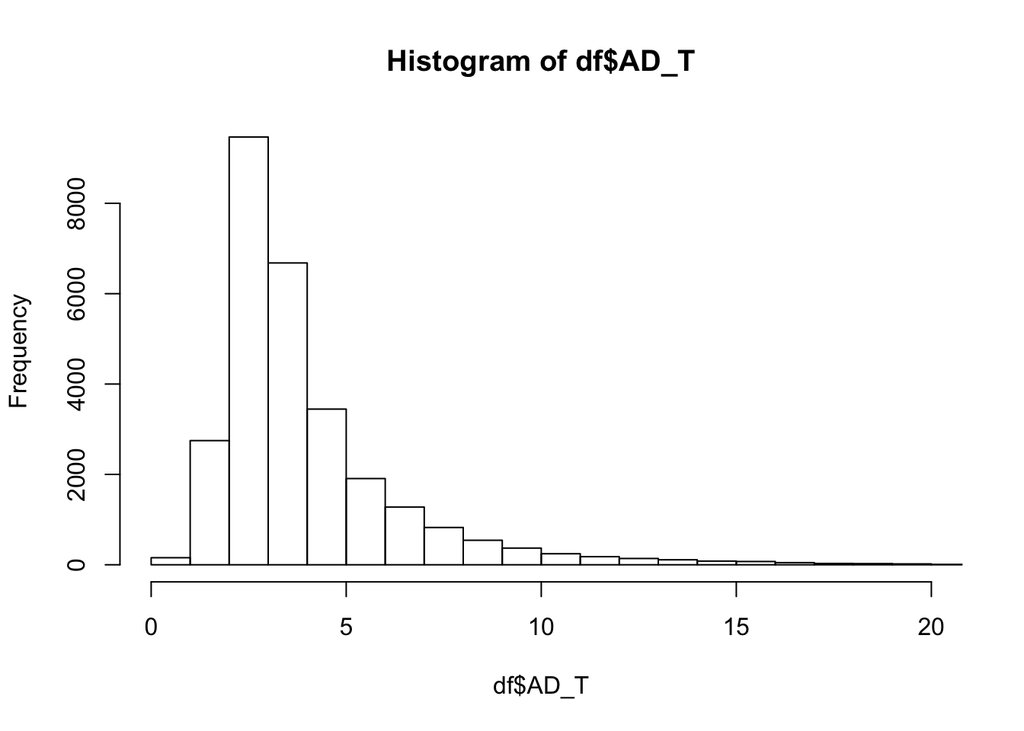

```r
hist(df$AD_T, xlim=c(0,20), breaks=100)
```

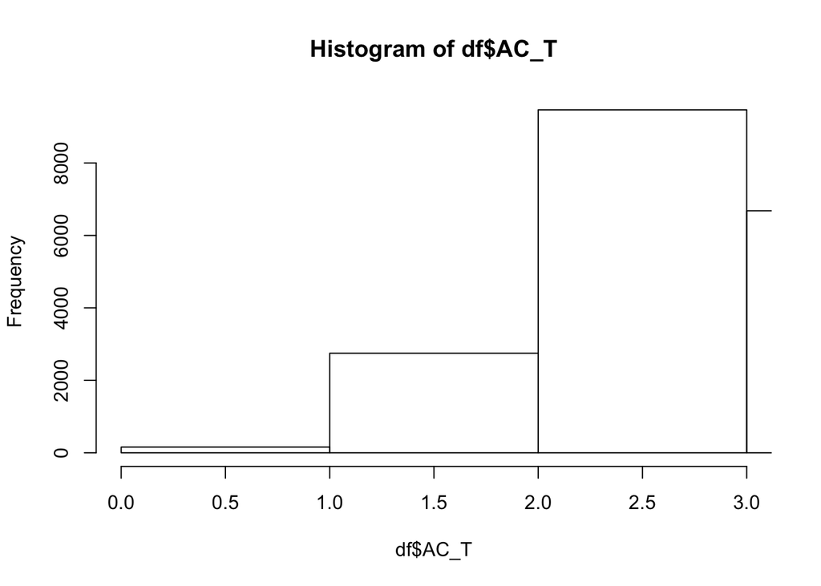

```r
#df[df$AD_T > 15,]$AD_T <- 15
hist(df$AC_T, xlim=c(0,3), breaks=100)
```

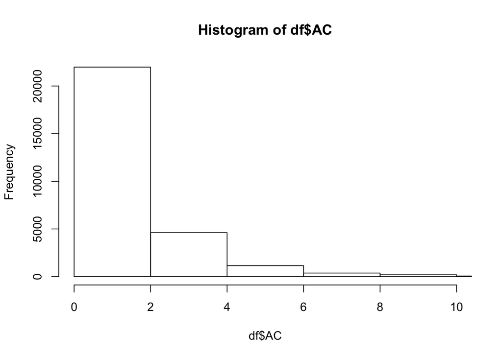

```r
# 2) AD_T. Is exactly the same as AC_T, remove.
#df <- df %>% dplyr::select(-AD_T)
# 3) NUM_TOOLS.
df$NUM_TOOLS <- ordered(df$NUM_TOOLS)
# 4) SAMPLE. Leave as is for now.
# 5) SOMATIC. Adjust to numeric as an experiment
df$SOMATIC <- as.character(df$SOMATIC)
#df[df$SOMATIC == 'SOMATIC',]$SOMATIC <- '1'
#df[df$SOMATIC == 'NONSOMATIC',]$SOMATIC <- '0'

# Round 2
# 6) TNCF_TSN. 49845 NA's, remove.
df <- df %>% dplyr::select(-TNCF_TSN)
# 7) CON. 22 levels, 320 NA's. Label these values as intergenic
df[is.na(df$CON),]$CON <- 'intergenic_variant'
# 8) AN. AN is the number of alleles in the entire cohort. (320 NAs)
# AN = AC * total samples with alt allele. AC is also NA in all cases. Assume 2.
df[is.na(df$AN),]$AN <- 2 * (df[is.na(df$AN),]$SAM_NUM)

# 9) SAM_NUM.
# 10) AC. 320 NA's. Assign all of them to 2.
# AC is the number of alleles within a sample. Let's just assume it's 2 for 51 NA values
df[is.na(df$AC),]$AC <- 2
#df[df$AC > 10,]$AC <- 10
hist(df$AC, xlim=c(0,10), breaks=10)
```

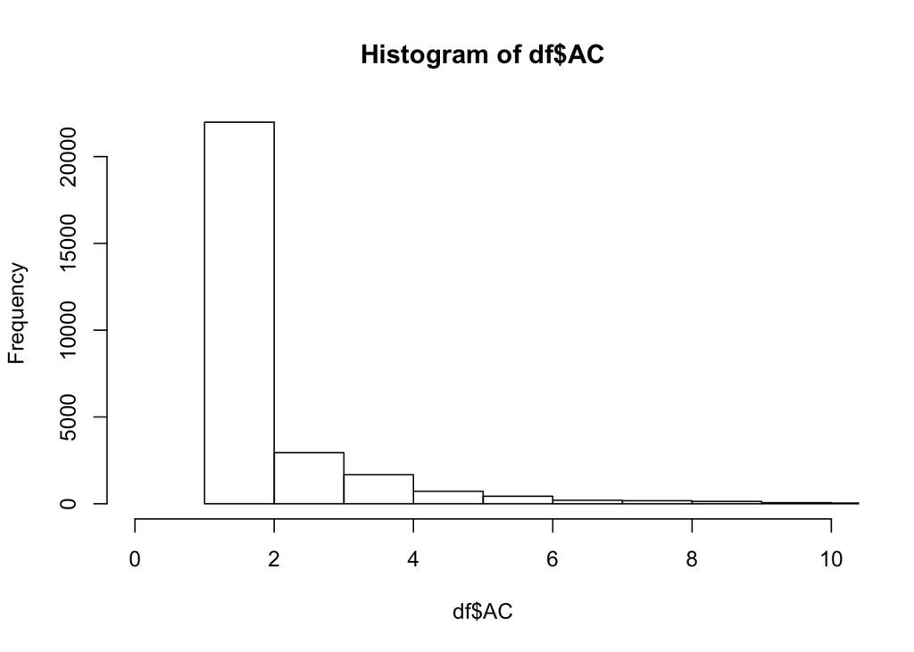

```r
# Reduce numeric to max of 1
hist(df$AC, xlim=c(0,10), breaks=20)
```

```r
# Round 3
# 11) MVJSDU. Convert all 5 caller factors to one facot to reduce levels to 53 or lower
df$MVJSDU <- as.factor(df$MVJSDU)
# 12) S. Leave as is.
# 13) IMPACT. 320 NA's. These values have been replaced with intergenic--MODIFIER
df[is.na(df$IMPACT),]$IMPACT <- 'MODIFIER'
# 14) ALTERATION. Leave as is.
# 15) CONTEXT. Leave as is.
# 16) CpG. Leave as is.
# 17) POWER. Leave as is.

################################################################################
####### Adjust Features and DataSet to Comply with Random Forest Algorithm #####
################################################################################

## Formating
# Rename TUM_TYPES
names(df)[names(df) == 'CGC_TUMTYPES-S'] <- 'CGC_TUMTYPES_S'
names(df)[names(df) == 'CGC_TUMTYPES-G'] <- 'CGC_TUMTYPES_G'
#summary(is.na(df))
# consider: 'CGC_TUMTYPES_G','CGC_SYNDROME','CGC_TISSUE','CGC_MOLGEN','CGC_ROLE','CGC_MUT','CGC'
# Remove predictors that are deemed irrelevent or redundent
lose <-c('ALLELE')
df <- df[ , !(names(df) %in% lose)]
# Predictors with too many NA's that cannot be compensated for
lose <- c('ID','altMQ_N','altBQ_N','altNM_N','zMQ_N','zBQ_N','SYMBOL','GENE','FEAT_TYPE',
          'FEAT','BIOTYPE','EXON','INTRON','HGVSc','HGVSp','cDNA_POS','CDS_POS','PRO_POS',
          'AA','CODONS','DIST','STRAND','SYMBOL_SOURCE','HGNC_ID','ENSP','SWISSPROT','TREMBL',
          'UNIPARC','SIFT','DOMAINS','HGVS_OFFSET','HUGO','CGC_TUMTYPES_S','CGC_MUT','TNCF_TSN',
          'TNCF_SAM','TNCF_VAC','TNCF_VAF','TNCF',
          "GT_N","CON","CGC_TUMTYPES_G","CGC_SYNDROME")
#df <- df[ , !(names(df) %in% lose)]

# Compensate for NA values for categorical variables
# CHROM has amny chromosome, reduce levels to major chromosomes
#df$CHROM <- as.character(df$CHROM)
#df[grepl("NT_", df$CHROM),]$CHROM <- 'Micro'
#df$CHROM <- as.factor(df$CHROM)

# Adjust NA values in high throughput manner when possible
easy_adjust <- c('CGC_TUMTYPES_G','CGC_SYNDROME','CGC_TISSUE','CGC_MOLGEN','CGC_ROLE','CGC')
#easy_adjust <- c('CGC_SYNDROME','CGC_TISSUE','CGC_MOLGEN','CGC_ROLE','CGC')

#summary(is.na(df))
for (p in easy_adjust) {
        df[[p]] <- as.character(df[[p]])
        df[is.na(df[[p]]),][[p]] <- 'NO'
        df[[p]] <- as.factor(df[[p]])
}

# Compensate for NA values for numerical variables

# Mapping quality variables (refMQ_N, altMQ_N,altMQ_T,refMQ_T)
# refMQ_N has 222 NA values, substitute with the mean reference allele MQ from tumor
# HC samples: refMQ_N ~ refMQ_T <- SAFE, low NA freq
df[is.na(df$refMQ_N),]$refMQ_N <- as.numeric(summary(df[is.na(df$refMQ_N),]$refMQ_T)[3])
# altMQ_T has 4 NA values. Replace values with altMQ_N.
#df[is.na(df$altMQ_T),]$altMQ_T <- df[is.na(df$altMQ_T),]$altMQ_N
# refMQ_T has 886 NA values. Replace values with refMQ_N
df[is.na(df$refMQ_T),]$refMQ_T <- df[is.na(df$refMQ_T),]$refMQ_N
# Base quality variables
# refBQ_N has 211 NA values.
# Step 1. Replace refBQ_N NA values with refBQ_T (147 NA values remianing)
df[is.na(df$refBQ_N),]$refBQ_N <- df[is.na(df$refBQ_N),]$refBQ_T
# Step 2. Replace refBQ_N NA values with altBQ_T (maintains the MQ unique to locus)
df[is.na(df$refBQ_N),]$refBQ_N <- df[is.na(df$refBQ_N),]$altBQ_T
# refMQ_T has NA when VAF_T is 0. Replace those 51 values with refMQ_N
#df[is.na(df$refMQ_T),]$refMQ_T <- df[is.na(df$refMQ_T),]$refMQ_N
# refBQ_T has NA when there are no reads supporting the reference allele, replace values with BQ of alt allele
df[is.na(df$refBQ_T),]$refBQ_T <- df[is.na(df$refBQ_T),]$altBQ_T
# refNM_T has NA when there are no reference reads in tumor. Replace those 51 values with 0.
df[is.na(df$refNM_T),]$refNM_T <- 0
# AN is the number of alleles in the entire cohort. AN = AC * total samples with alt allele
#df[is.na(df$AN),]$AN <- (df[is.na(df$AN),]$AC) * (df[is.na(df$AN),]$SAM_NUM)
# refMN_N is missing one value, just put the mean in there
df[is.na(df$refNM_N),]$refNM_N <- as.numeric(summary(df$refNM_N)[[4]])
# zMQ_T replace with 0 (crude)
df[is.na(df$zMQ_T),]$zMQ_T <- 0
# zBQ_T replace with 0 (crude)
df[is.na(df$zBQ_T),]$zBQ_T <- 0

# Adjust characters to facotrs
df$POWER <- as.factor(df$POWER)
#summary(df)
#summary(is.na(df))
# Convert numeric character columns to numeric
df$VAF_T <- as.numeric(df$VAF_T)

# Convert character vectors to factors
cvecs <- as.vector(names(df[, sapply(df, class) == 'character']))
# Iterate through each column and transform
for (char_vec in cvecs) {
        #print(char_vec)
        #print(table(factor(df[[char_vec]])))
        df[[char_vec]] <- as.factor(df[[char_vec]])
}

#relabel certain columns to ordinal
#ordinals <- c('NUM_TOOLS','FILTER')
#for (ord in ordinals) {
#        df[[ord]] <- ordered(as.factor(df[[ord]]))
#}

################################################################################

################################################################################
############## Choose the Dependent and Response Variables #####################
################################################################################

# Determine which columns should be considered in the model (response and dependents)
response <- 'VALIDATION'
dependents <- names(df)
# Custom column removal
drops <- c('VALIDATION',"VAR_TYPE","POS","CHROM","REF","ALT")
drops <- append(drops, lose)
dependents <- dependents[dependents %!in% drops]

################################################################################
```

## Build Training Set

```r
################################################################################
################# Build: Training Set ##########################################
################################################################################

# Generate the training set
train_df <- dplyr::filter(df, VALIDATION %in% c('TP', 'FP'))
# Already deduped above
#train_df <- train_df[!duplicated(train_df[,c('CHROM','POS','REF','ALT','SAMPLE')]),]

################################################################################
```

Training set is small and unbalanced

```r
dim(train_df)
```

```
## [1]  63 100
```

```r
table(train_df$VALIDATION)
```

```
##
## FP TP
## 45 18
```

## Build Model Formulas

```r
################################################################################
################# Build: Formula ###############################################
################################################################################

# Create the appropriate formula: (only important features)
formula <- as.formula(paste(response, paste(dependents, collapse=" + "), sep=" ~ "))
#feats <- pc2[pc2 %!in% c('CHROM','POS','REF','ALT')]
#formula <- as.formula(paste(response, paste(dependents, collapse=" + "), sep=" ~ "))

################################################################################
```

Model Formula

```r
print(formula)
```

```
## VALIDATION ~ FILTER + SOMATIC + MVJSDU + NUM_TOOLS + refMQ_N +
##     refBQ_N + refNM_N + fetSB_N + fetCD_N + VAF_N + GT_T + refMQ_T +
##     altMQ_T + refBQ_T + altBQ_T + refNM_T + altNM_T + fetSB_T +
##     fetCD_T + zMQ_T + zBQ_T + VAF_T + SAMPLE + AC + AN + IMPACT +
##     CGC_TISSUE + CGC_MOLGEN + CGC_ROLE + CGC + SAM_NUM + RF_N +
##     RR_N + AF_N + AR_N + RF_T + RR_T + AF_T + AR_T + RC_N + RD_N +
##     AC_N + AD_N + RC_T + RD_T + AC_T + AD_T + M + V + J + S +
##     POWER
```

## Build Test Set

The testing set was reduced to only indels called by 3 or 4 callers. The trianing data, the model, and my skills are not strong enough to differentiate accurate calls from indels of 2 or more callers.

```r
################################################################################
################# Build: Test Dataset ##########################################
################################################################################

# Extract the values in the data that have undergone validation
test_df <- dplyr::filter(df, NUM_TOOLS >= 3 & VALIDATION %!in% c('TP', 'FP'))

################################################################################
```

Test Set

```r
print(dim(test_df))
```

```
## [1] 4966  100
```

Ensure trianing set and test set in good order

```r
################################################################################
##########  Ensure trianing set and test set are in good order  ################
################################################################################

# Ensure the levels in the trianing set are the only levels represented in the test set
# This is not a fool-proof command, make sure to manually inspect or update command as needed
for (f in dependents) {
        # Only apply to columns that are factors
        if (is.factor(test_df[[f]])) {
                if (sort(unique(train_df[[f]])) != sort(unique(test_df[[f]]))) {
                        print(f)
                        print('training')
                        print(unique(train_df[[f]]))
                        print('testing')
                        print(unique(test_df[[f]]))
                }
        }
}
```

```
## [1] "FILTER"
## [1] "training"
## [1] PASS    LowQual
## Levels: LowQual PASS
## [1] "testing"
## [1] PASS
## Levels: LowQual PASS
## [1] "SOMATIC"
## [1] "training"
## [1] SOMATIC    NONSOMATIC
## Levels: NONSOMATIC SOMATIC
## [1] "testing"
## [1] SOMATIC
## Levels: NONSOMATIC SOMATIC
## [1] "MVJSDU"
## [1] "training"
## [1] 1,1,1,0 1,1,0,0 1,1,1,1 0,1,1,1 1,0,1,0 1,1,0,1 0,1,1,0 0,0,1,1
## 11 Levels: 0,0,1,1 0,1,0,1 0,1,1,0 0,1,1,1 1,0,0,1 1,0,1,0 ... 1,1,1,1
## [1] "testing"
## [1] 1,1,1,0 1,1,1,1 1,1,0,1 1,0,1,1 0,1,1,1
## 11 Levels: 0,0,1,1 0,1,0,1 0,1,1,0 0,1,1,1 1,0,0,1 1,0,1,0 ... 1,1,1,1
## [1] "NUM_TOOLS"
## [1] "training"
## [1] 3 2 4
## Levels: 2 < 3 < 4
## [1] "testing"
## [1] 3 4
## Levels: 2 < 3 < 4
```

```r
# Double check factor level length is under 53 for all factors
lvl_cols <- c()
# Remove columns with more than 53 categories
for (col in dependents) {
        factor_len <- length(levels(train_df[[col]]))
        if (factor_len >= 53) {
                lvl_cols <- append(lvl_cols, col)
                print(factor_len)
                print(col)
        }
}

# This approach suggests 6 variables is most sutable
# extract the 8 most suitable variables
#priority_cols_all <- priority_cols
#red_deps <- names(priority_cols)
#formula <- as.formula(paste(response, paste(red_deps, collapse=" + "), sep=" ~ "))
#length(priority_cols)

################################################################################
```

## Model Development

```r
################################################################################
############# Model Development ################################################
################################################################################

# Make sure test dataset has no trianing data values
#table(test_df$VALIDATION)

# Perform a random forest analysis on the training data
# (random forest does not handle missing values well at all)
# (here we will use the entire validation data)
set.seed(123)
summary(train_df)
```

```
##      CHROM         POS                 REF          ALT
##  2      :14   Min.   :  2467675   A      : 9   A      :19
##  10     : 8   1st Qu.:  7905723   C      : 8   T      :11
##  1      : 7   Median : 25964062   T      : 7   AT     : 5
##  3      : 7   Mean   : 34726403   G      : 4   C      : 5
##  12     : 6   3rd Qu.: 50222872   TTC    : 3   CA     : 4
##  11     : 3   Max.   :174221429   AAAAAAG: 2   CT     : 3
##  (Other):18                       (Other):30   (Other):16
##           ID         FILTER         SOMATIC       MVJSDU   NUM_TOOLS
##  rs13543530: 0   LowQual:29   NONSOMATIC:29   1,1,0,0:15   2:29
##  rs13549392: 0   PASS   :34   SOMATIC   :34   1,1,1,0:12   3:24
##  rs13550321: 0                                1,0,1,0:11   4:10
##  rs13606495: 0                                1,1,1,1:10
##  rs13606639: 0                                0,1,1,1: 7
##  (Other)   : 0                                1,1,0,1: 5
##  NA's      :63                                (Other): 3
##   GT_N       refMQ_N         altMQ_N       refBQ_N         altBQ_N
##  ./.: 0   Min.   :47.35   Min.   : NA   Min.   :31.38   Min.   : NA
##  0/0:63   1st Qu.:60.00   1st Qu.: NA   1st Qu.:35.95   1st Qu.: NA
##  0/1: 0   Median :60.00   Median : NA   Median :37.00   Median : NA
##  1/1: 0   Mean   :59.70   Mean   :NaN   Mean   :36.40   Mean   :NaN
##           3rd Qu.:60.00   3rd Qu.: NA   3rd Qu.:37.47   3rd Qu.: NA
##           Max.   :65.79   Max.   : NA   Max.   :38.00   Max.   : NA
##                           NA's   :63                    NA's   :63
##     refNM_N          altNM_N       fetSB_N     fetCD_N      zMQ_N
##  Min.   :0.0000   Min.   : NA   Min.   :1   Min.   :1   Min.   : NA
##  1st Qu.:0.1131   1st Qu.: NA   1st Qu.:1   1st Qu.:1   1st Qu.: NA
##  Median :1.3636   Median : NA   Median :1   Median :1   Median : NA
##  Mean   :1.6765   Mean   :NaN   Mean   :1   Mean   :1   Mean   :NaN
##  3rd Qu.:2.4143   3rd Qu.: NA   3rd Qu.:1   3rd Qu.:1   3rd Qu.: NA
##  Max.   :6.0667   Max.   : NA   Max.   :1   Max.   :1   Max.   : NA
##                   NA's   :63                            NA's   :63
##      zBQ_N         VAF_N    GT_T       refMQ_T        altMQ_T
##  Min.   : NA   Min.   :0   0/1:61   Min.   :36.0   Min.   :53.10
##  1st Qu.: NA   1st Qu.:0   1/1: 2   1st Qu.:60.0   1st Qu.:60.00
##  Median : NA   Median :0            Median :60.0   Median :65.22
##  Mean   :NaN   Mean   :0            Mean   :59.2   Mean   :64.52
##  3rd Qu.: NA   3rd Qu.:0            3rd Qu.:60.0   3rd Qu.:68.57
##  Max.   : NA   Max.   :0            Max.   :65.0   Max.   :71.25
##  NA's   :63
```

[output cut: 185 more lines]

[output not shown]

```r
rf_model <- randomForest(formula = formula,
                         data = train_df,
                         na.action = na.omit,
                         type = classification,
                         ntree = 1000,
                         mtry = 5)

# Examine general stats about the model
print(rf_model)
```

```
##
## Call:
##  randomForest(formula = formula, data = train_df, type = classification,      ntree = 1000, mtry = 5, na.action = na.omit)
##                Type of random forest: classification
##                      Number of trees: 1000
## No. of variables tried at each split: 5
##
##         OOB estimate of  error rate: 7.94%
## Confusion matrix:
##    FP TP class.error
## FP 42  3  0.06666667
## TP  2 16  0.11111111
```

```r
# Examine Variable Importance
#class(rf_model)
priority_cols <- rev(importance(rf_model)[order(importance(rf_model)),])
# Remove predictors with no affect and update formula
priority_cols <- priority_cols[priority_cols > 0.01]
red_deps <- names(priority_cols)
formula <- as.formula(paste(response, paste(red_deps, collapse=" + "), sep=" ~ "))
length(priority_cols)
```

```
## [1] 43
```

```r
names(priority_cols)
```

```
##  [1] "MVJSDU"     "SAMPLE"     "altNM_T"    "zMQ_T"      "altMQ_T"
##  [6] "refNM_N"    "refNM_T"    "NUM_TOOLS"  "VAF_T"      "S"
## [11] "IMPACT"     "POWER"      "RR_T"       "RC_T"       "RR_N"
## [16] "refBQ_N"    "RC_N"       "zBQ_T"      "RF_T"       "refBQ_T"
## [21] "CGC_ROLE"   "AD_T"       "RF_N"       "altBQ_T"    "CGC_MOLGEN"
## [26] "AR_T"       "J"          "AC_T"       "M"          "AC"
## [31] "SAM_NUM"    "FILTER"     "AN"         "refMQ_N"    "CGC_TISSUE"
## [36] "AF_T"       "fetSB_T"    "refMQ_T"    "SOMATIC"    "CGC"
## [41] "V"          "RD_T"       "RD_N"
```

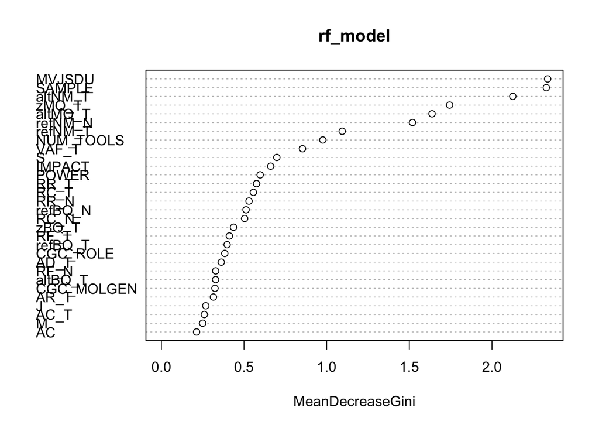

```r
varImpPlot(rf_model)
```

```r
# Random forest provides a built-in validation set without any extra work
# Grab the OOB error matrix and examine
err <- rf_model$err.rate
head(err)
```

```
##             OOB         FP        TP
## [1,] 0.08695652 0.05263158 0.2500000
## [2,] 0.21212121 0.11538462 0.5714286
## [3,] 0.19565217 0.09090909 0.4615385
## [4,] 0.25925926 0.12500000 0.6428571
## [5,] 0.21052632 0.11904762 0.4666667
## [6,] 0.22033898 0.11627907 0.5000000
```

```r
# Look at final OOB error rate (last row in err matrix)
oob_err <- err[nrow(err), "OOB"]
print(oob_err)
```

```
##        OOB
## 0.07936508
```

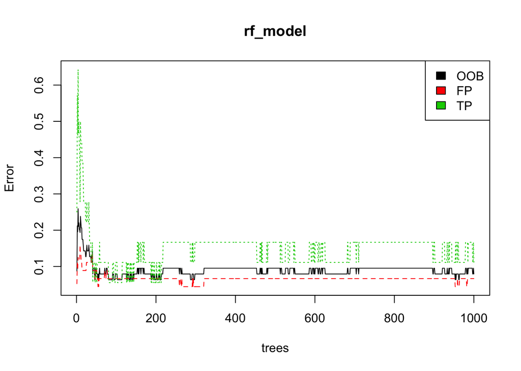

```r
# Plot the model trained in the previous exercise
plot(rf_model)

# Add a legend since it doesn't have one by default
legend(x = "topright",
       legend = colnames(err),
       fill = 1:ncol(err))
```

```r
# Construct object needed to tune the model
train_predictor_df <- train_df[ ,dependents]
train_response_vector <- as.factor(train_df$VALIDATION)

# Tune the model
# Train the mtry parameter based on the OOB error
trees <- c(200, 400, 1000, 2000)
for (ntree in trees) {
        set.seed(1)
        res <- tuneRF(x = train_predictor_df,
                      y = train_response_vector,
                      ntreeTry = ntree,
                      stepFactor = .5,
                      na.action = na.omit)
}
```

```
## mtry = 7  OOB error = 7.94%
## Searching left ...
## mtry = 14    OOB error = 7.94%
## 0 0.05
## Searching right ...
## mtry = 3     OOB error = 9.52%
## -0.2 0.05
```

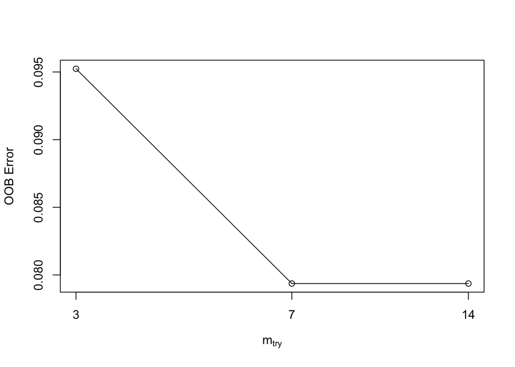

```
## mtry = 7  OOB error = 7.94%
## Searching left ...
## mtry = 14    OOB error = 11.11%
## -0.4 0.05
## Searching right ...
## mtry = 3     OOB error = 6.35%
## 0.2 0.05
## mtry = 1     OOB error = 17.46%
## -1.75 0.05
```

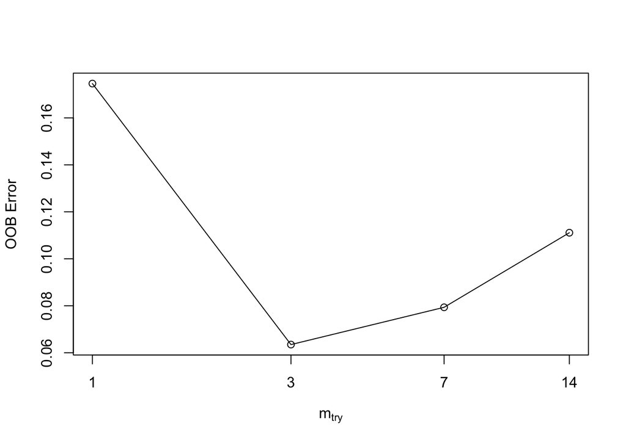

```
## mtry = 7  OOB error = 7.94%
## Searching left ...
## mtry = 14    OOB error = 9.52%
## -0.2 0.05
## Searching right ...
## mtry = 3     OOB error = 7.94%
## 0 0.05
```

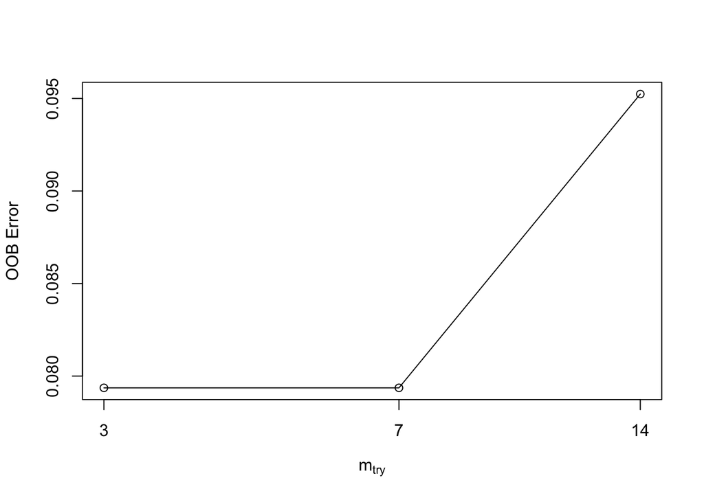

```
## mtry = 7  OOB error = 7.94%
## Searching left ...
## mtry = 14    OOB error = 7.94%
## 0 0.05
## Searching right ...
## mtry = 3     OOB error = 6.35%
## 0.2 0.05
## mtry = 1     OOB error = 20.63%
## -2.25 0.05
```

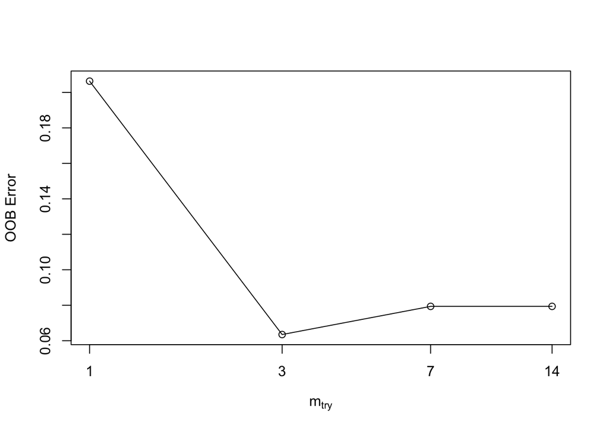